[figure not shown]

```python
import qrcode
import numpy as np
import matplotlib.pyplot as plt
def plot(*funcs, x_min=-5, x_max=5):
    plt.grid(color='gray', linestyle='-', linewidth=1)
    xs = np.linspace(x_min, x_max, 50)
    for f in funcs:
        plt.plot(xs, np.vectorize(f)(xs))

qrcode.make('https://github.com/angatha/MatheVorkurs')
```

# Links

Stundenplan [html](http://intranet-i.ostfalia.de/) [ical](https://intranet-i.ostfalia.de/ical/) [spluseins](https://spluseins.de/)

[Semester/Deutschlandticket](https://asta.ostfalia.de/index.php/link-und-datenschutz-zum-dsemti/)

[Ostfalia-Card](https://www.ostfalia.de/hochschule/campus-einrichtungen/rechenzentrum/hilfe-vom-it-service-desk#c10514) Abholung im [Rechenzentrum](https://maps.app.goo.gl/y7wjQdDeAbwsFewk8)

[Zusatzdokument](https://www.ostfalia.de/hochschule/fakultaeten/fakultaet-informatik/fakultaetsteam/dr-susanne-bellmer#c29575-t)

# Tag 4

Zusätliche Aufgaben sind unten angefügt.

## 39

### a)

$\begin{align} 8*(x-1)-5*(y+1) &= 12 \\ 13*(x+2)-6*(y+2) &= 61 \\ \\ \Leftrightarrow 8x-8-5y-5 &= 12 |+13 \\ \Leftrightarrow 13x+26-6y-12 &= 61 |-14 \\ \\ \Leftrightarrow 8x-5y &= 25 | *6 \\ \Leftrightarrow 13x-6y &= 47 | *5\\ \\ \Leftrightarrow 48x-30y &= 150 \\ \Leftrightarrow 65x-30y &= 235 | -\\ \\ \Leftrightarrow -17x &= -85 | :(-17) \\ \Leftrightarrow x &= 5 \\ \\ 8x-5y &= 25 | x = 5 \\ \\ \Leftrightarrow 8*(5)-5y &= 25 | -8*5\\ \\ \Leftrightarrow -5y &= -15 | :(-5) \\ \\ \Leftrightarrow y &= 3 \end{align}$

# 3.1.1 Eine lineare Gleichung

## 1

Eine Großmutter ist 84 Jahre alt, ihre Enkelin ist 8 Jahre alt.

### a)

In wie vielen Jahren wird die Großmutter fünf mal so alt wie die Enkelin sein?

$84 + j = 5 * (8 + j)$

$\Leftrightarrow 84 + j = 40 + 5j | -j -40$

$\Leftrightarrow 44 = 4j | /4$

$\Leftrightarrow 11= j$

### b)

Vor wie vielen Jahren war sie zwanzigmal so alt?

$84 - j = 20 * (8 - j)$

$\Leftrightarrow 84 - j = 160 - 20j | +20j - 84$

$\Leftrightarrow 19j = 76 | /19$

$\Leftrightarrow j = 4$

## 2

### a)

Gegeben Rechteck mit $a * b = A$ mit $a > b$

$\begin{align} (a - 2 \text{ cm})*(b + 2 \text{ cm}) &= a * b + 4 \text{ cm}^2 \\ (a + 3 \text{ cm})*(b + 3 \text{ cm}) &= a * b + 57 \text{ cm}^2 \\ \\ \Leftrightarrow ab+2a\text{ cm}-2b\text{ cm}-4\text{ cm}^2&= a * b + 4 \text{ cm}^2 | -ab \\ \Leftrightarrow ab+3a\text{ cm}+3b\text{ cm}+9\text{ cm}^2 &= a * b + 57 \text{ cm}^2 | -ab \\ \\ \Leftrightarrow 2a\text{ cm}-2b\text{ cm}-4\text{ cm}^2&= 4 \text{ cm}^2 | /2 \\ \Leftrightarrow 3a\text{ cm}+3b\text{ cm}+9\text{ cm}^2 &= 57 \text{ cm}^2 | /3 \\ \\ \Leftrightarrow a\text{ cm}-b\text{ cm}-2\text{ cm}^2&= 2 \text{ cm}^2 | +2 \text{ cm}^2 \\ \Leftrightarrow a\text{ cm}+b\text{ cm}+3\text{ cm}^2 &= 19 \text{ cm}^2 | -3 \text{ cm}^2 \\ \\ \Leftrightarrow a\text{ cm}-b\text{ cm}&= 4 \text{ cm}^2 \\ \Leftrightarrow a\text{ cm}+b\text{ cm}&= 16 \text{ cm}^2 \\ \end{align}$

Addieren bzw. subtrahieren

$2a\text{ cm} = 20\text{ cm}^2 | / 2\text{ cm}$

$\Leftrightarrow a = 10 cm$

$-2b\text{ cm} = (4-16)\text{ cm}^2 | / 2\text{ cm}$

$\Leftrightarrow b = 6 cm$

Die Ergebnisse erfüllen $a > b$. Damit ist dies tatsächlich die Lösung.

### b)

$\begin{align} 2a+b &= 37\text{ cm} \\ b &= a - 5\text{ cm} \\ \\ 2a+(a - 5\text{ cm}) &= 37\text{ cm} \\ \Leftrightarrow 2a+a - 5\text{ cm} &= 37\text{ cm} | + 5\text{ cm} \\ \Leftrightarrow 3a &= 42\text{ cm} | 3\\ \Leftrightarrow a &= 14\text{ cm} \\ \\ b &= a - 5\text{ cm} \\ \Leftrightarrow b &= 14\text{ cm} - 5\text{ cm} \\ \Leftrightarrow b &= 9\text{ cm} \\ \end{align}$

Erfüllt die Lösung die Dreiecksungleichung?

$a + a > b\\\Leftrightarrow 14\text{ cm} + 14\text{ cm} > 9\text{ cm}$

$a + b > a\\\Leftrightarrow 14\text{ cm} + 9\text{ cm} > 14\text{ cm}$

Ja

## 3

$\begin{align} r &= 3l \\ 3(r - 30) &= l + 30 \\ \\ 3(3l - 30) &= l + 30 \\ \Leftrightarrow 3*3l - 3*30 &= l + 30 \\ \Leftrightarrow 9l - 90 &= l + 30 | -l + 90 \\ \Leftrightarrow 8l &= 120 | /8 \\ \Leftrightarrow l &= 15 \\ \\ r &= 3l \\ \Leftrightarrow r &= 3*15 \\ \Leftrightarrow r &= 45 \\ \end{align}$

Rechts sind auch mindestens dreißig Nüsse. Daher ist die Lösung gültig.

## 4

$\begin{align} m + 16 &= 2(t+16) \\ m + t &= 40 | -t\\ \\ \Leftrightarrow m + 16 &= 2(t+16) \\ \Leftrightarrow m &= 40 - t \\ \\ (40 - t) + 16 &= 2(t+16) \\ \Leftrightarrow 40 - t + 16 &= 2t+2*16 \\ \Leftrightarrow 56 - t &= 2t+32 | -56-2t \\ \Leftrightarrow -3t &= -24 | /(-3) \\ \Leftrightarrow t &= 8 \\ \\ m &= 40 - t \\ \Leftrightarrow m &= 40 - 8 \\ \Leftrightarrow m &= 32 \\ \end{align}$

## 5

### a)

$\begin{align} a + b &= 25 \\ a - b &= 7 \\ \end{align}$

Additionsverfahren

$\begin{align} 2a &= 25 + 7 \\ \Leftrightarrow 2a &= 32 | /2 \\ \Leftrightarrow a &= 16 \\ \end{align}$

$\begin{align} a - b &= 7 \\ \Leftrightarrow 16 - b &= 7 | +b-7 \\ \Leftrightarrow 9 &= b \\ \end{align}$

### b)

$\begin{align} 4a - 3b &= 18 | *3 \\ 3a + 10 &= 14b | *4 \\ \\ \Leftrightarrow 12a - 9b &= 54 \\ \Leftrightarrow 12a + 40 &= 56b \\ \end{align}$

Subtrahieren (Additionsverfahren)

$\begin{align} -9b - 40 &= 54 - 56b | + 56b + 40 \\ \Leftrightarrow 47b &= 94 | /47 \\ \Leftrightarrow b &= 2 \\ \end{align}$

$\begin{align} 3a + 10 &= 14b | - 10\\ \Leftrightarrow 3a &= 14*2 - 10 \\ \Leftrightarrow 3a &= 18 | /3 \\ \Leftrightarrow a &= 6 \\ \end{align}$

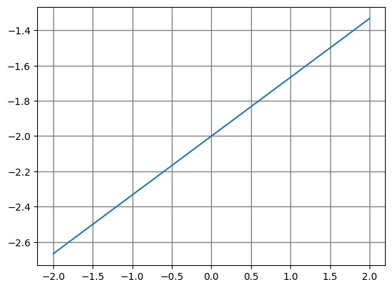

```python
plot(lambda x: x/3-2, x_min = -2, x_max = 2)
```

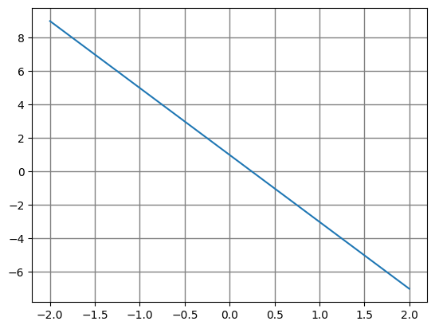

```python
plot(lambda x: -4*x+1, x_min = -2, x_max = 2)
```

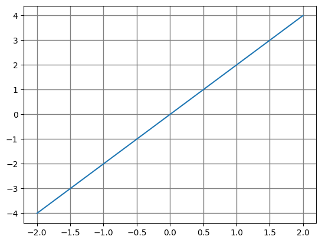

```python
plot(lambda x: 2*x, x_min = -2, x_max = 2)
```

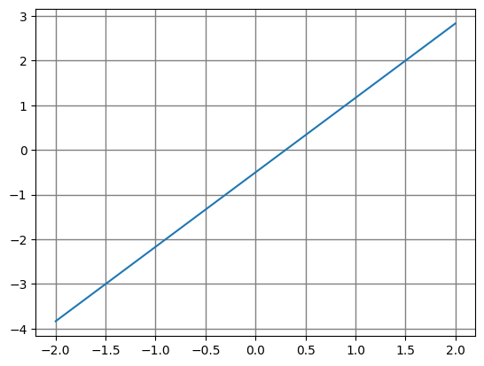

```python
plot(lambda x: 5/3*x-0.5, x_min = -2, x_max = 2)
```

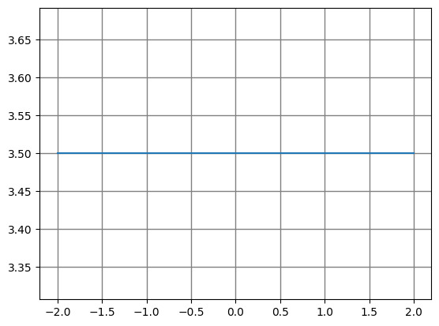

```python
plot(lambda x: 3.5, x_min = -2, x_max = 2)
```

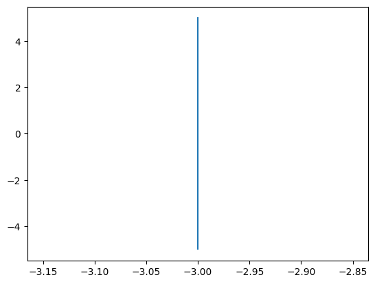

```python
plt.plot([-3,-3],[-5,5])
```

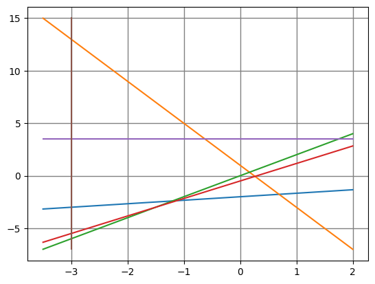

```python
plot(lambda x: x/3-2, lambda x: -4*x+1, lambda x: 2*x, lambda x: 5/3*x-0.5, lambda x: 3.5, x_min = -3.5, x_max = 2)
plt.plot([-3,-3],[-7,15])
```

Erhöht man die Höhe eines Dreiecks um 3, so wächst der Flächeninhalt um 7. Verringert man hingegen die Höhe um 1, so sinkt er um 3.

Es gibt daher folgende Gleichungen mit dem Flächeninhalt $A$, der Seite $c$ und der Höhe über der Seite $c$ als $h_c$.

$\begin{align} A &= \frac{1}{2}h_cc \\ A + 7 &= \frac{1}{2}(h_c+3)c \\ A - 3 &= \frac{1}{2}(h_c-1)c \\ \end{align}$

Es werden beige gleichungen zu $c$ umgestellt. Es entfällt der nicht lineare Summang $h_cc$ durch subtrahieren auf beiden Seiten.

$\begin{align} \frac{1}{2}h_cc + 7 &= \frac{1}{2}(h_c+3)c |*2 \\ \frac{1}{2}h_cc - 3 &= \frac{1}{2}(h_c-1)c |*2 \\ \\ h_cc + 14 &= (h_c+3)c \\ h_cc - 6 &= (h_c-1)c \\ \\ h_cc + 14 &= h_cc+3c |-h_cc \\ h_cc - 6 &= h_cc-c |-h_cc \\ \\ 14 &= 3c \\ 6 &=-c \\ \\ \frac{14}{3} &= c \\ -6 &=c \\ \end{align}$

Zwei verschiedene Werte für $c$. Daher gibt es keine Lösung.

$\begin{align} 2a + 2b + 6c - 31 &= 19 | +31\\ a + b + 3c &= 25 \\ -4a + b &= 10 - 3a + c |+3a - c\\ \\ 2a + 2b + 6c &= 50 |/2\\ a + b + 3c &= 25 \\ -a + b - c &= 10\\ \\ a + b + 3c &= 25 \\ a + b + 3c &= 25 \\ -a + b - c &= 10\\ \end{align}$

Zwei Gleichungen sind identisch. Effektiv gibt es also nur zwei Gleichungen für drei Unbekannte. Es wird also mehr als eine Lösung geben. Wird wählen $c$ als freie Variable in der Lösung.

$\begin{align} A*B &= \frac{1}{8} \\ A*\frac{B}{2} &= \frac{1}{16} \\ \frac{A}{B} &= \frac{B}{C} \\ C &= \frac{A}{2} \\ \end{align}$

## Weitere Übungsaufgaben

### b)

$\begin{align} 3a + 2b &= 2 \\ a - b &= 4 |*2\\ \\ 3a + 2b &= 2 \\ 2a - 2b &= 8 \\ \\ 3a + 2b &= 2 \\ 5a &= 10 | /5\\ \\ 3a + 2b &= 2 \\ a &= 2 \\ \\ 3*(2) + 2b &= 2 | -6\\ 2b &= -4 | /2\\ b &= -2\\ \end{align}$

### c)

$\begin{align} 7b - 3 &= 8 + 2a|-2a+3\\ 3a - 12 &= b |-b+12\\ \\ -2a + 7b &= 11 \\ 3a - b &= 12 |*7\\ \\ -2a + 7b &= 11 \\ 21a - 7b &= 84 \\ \\ -2a + 7b &= 11 \\ 19a &= 95 |/19\\ \\ -2a + 7b &= 11 \\ a &= 5 \\ \\ -2*5 + 7b &= 11 | +10 \\ 7b &= 21 |/7 \\ b &= 3 \end{align}$

### d)

$\begin{align} -2b + 3a &= c - 1|-c \\ a - b &= c|-c \\ 3a + 2b + c - 1 &= 10|+1 \\ \\ 3a - 2b - c&= -1 \\ a - b - c &= 0 |*3\\ 3a + 2b + c &= 11 \\ \\ 3a - 2b - c&= -1 \\ 3a - 3b - 3c &= 0\\ 3a + 2b + c &= 11 \\ \\ 3a - 2b - c&= -1 \\ (3a - 3b - 3c) - (3a - 2b - c) &= (0) - (-1)\\ (3a + 2b + c) - (3a - 2b - c) &= (11) - (-1) \\ \\ 3a - 2b - c&= -1 \\ -b - 2c &= 1 |*4\\ 4b + 2c &= 12 \\ \\ 3a - 2b - c&= -1 \\ -4b - 8c &= 4\\ 4b + 2c &= 12 \\ \\ 3a - 2b - c&= -1 \\ -4b - 8c &= 4\\ -6c &= 16 |/(-6)\\ \\ 3a - 2b - c&= -1 \\ -4b - 8c &= 4\\ c &= -\frac{8}{3}\\ \\ -4b - 8*(-\frac{8}{3}) &= 4 | /(-4)\\ b +2*(-\frac{8}{3}) &= -1\\ b - \frac{16}{3} &= -1|+\frac{16}{3}\\ b &= \frac{13}{3} \\ \\ 3a - 2*(\frac{13}{3}) - (-\frac{8}{3})&= -1 \\ 3a - \frac{26}{3} + \frac{8}{3}&= -1 \\ 3a - \frac{18}{3}&= -1 |+\frac{18}{3}\\ 3a&= \frac{15}{3} | /3\\ a&= \frac{5}{3}\\ \end{align}$

Weitere mit Rechenweg

### a)

$\begin{align} a + b &= 3a \\ a - b &= 2b | +b \\ \\ a &= 3b \\ 3b + b &= 3(3b)| - 9b\\ -5b &= 0 | /(-5) \\ \\ b &= 0\\ \\ a + 0 &= 3a | -3a\\ -2a &= 0 | /(-2) \\ a &= 0 \end{align}$

### b)

$\begin{align} 2a + b &= 17 | *5 \\ 10a + 5b &= 85 \\ \\ 10a + 5b &= 85 \\ \end{align}$

Effektiv nur eine Gleichung (oder anders: beide Gleichungen beschreiben die selbe Gerade). Daher unendlich viele Lösungen.

### c)

$\begin{align} 2x + b &= 17 | -2x \\ b &= 17 - 2x \end{align}$